# Lab-07

# Random Forests

First will will need to load the dplyr library, so we can read in csv files.

```r
library(dplyr)
titanic3 = read.csv("..\\..\\Week08\\titanic3.cSV", header = TRUE)
```

Once the data has been load, We can remove features from the dataset that will not be require for our tree models.

```r
titanic3=select(titanic3, -name, -ticket, -boat, -body, -home.dest, -cabin) %>% mutate(embarked = factor(embarked),sex = factor(sex), pclass=factor(embarked))
summary(titanic3)
```

```
##  pclass     survived         sex           age              sibsp
##   :  3   Min.   :0.000         :  1   Min.   : 0.1667   Min.   :0.0000
##  C:270   1st Qu.:0.000   female:466   1st Qu.:21.0000   1st Qu.:0.0000
##  Q:123   Median :0.000   male  :843   Median :28.0000   Median :0.0000
##  S:914   Mean   :0.382                Mean   :29.8811   Mean   :0.4989
##          3rd Qu.:1.000                3rd Qu.:39.0000   3rd Qu.:1.0000
##          Max.   :1.000                Max.   :80.0000   Max.   :8.0000
##          NA's   :1                    NA's   :264       NA's   :1
##      parch            fare         embarked
##  Min.   :0.000   Min.   :  0.000    :  3
##  1st Qu.:0.000   1st Qu.:  7.896   C:270
##  Median :0.000   Median : 14.454   Q:123
##  Mean   :0.385   Mean   : 33.295   S:914
##  3rd Qu.:0.000   3rd Qu.: 31.275
##  Max.   :9.000   Max.   :512.329
##  NA's   :1       NA's   :2
```

## Part 1: Feature Transformation

We will first need to clean and transform the data so it is optimised for our model. We will initially add a new variable survived01, which is a categorical equivalent of survived.

```r
titanic3$survived01 = as.factor(titanic3$survived)

append(titanic3$survived01, titanic3)
```

[output not shown]

[output cut: 4744 more lines]

[output not shown]

## Part 2: Build a forest

To use the random forest model, we will need to load the relevant library.

```r
# install package
library(randomForest)
```

Random forest can use only complete records. We will removed any observation that does not have values for all the predictor and target variables.

```r
# remove rows with missing data
titanic.clean <- na.omit(titanic3)
```

## Part 3: Split the data

We can now split the data into training and test sets.

```r
set.seed(1)

# split the data in half

# indices
train_index <- sample(nrow(titanic.clean), nrow(titanic.clean)/2)

# assign data
train <- titanic.clean[train_index, ]
test <- titanic.clean[-train_index, ]
```

We can also assign a couple of new variables, which will be the expected result from the test set. These can be used to construct the confusion matrix.

```r
# target variable from text set
actual <- titanic.clean[-train_index, "survived"]

actual01 <- titanic.clean[-train_index, "survived01"]
```

## Part 4: Build random forest model with numeric target variable

We will now build a regression random forest model with survived as the target. We will use all other variables, except survided01, as predictors.

```r
set.seed(1)

rf.titanic <- randomForest(survived ~ . -survived01, data = train, mtry = 7,importance=TRUE)
```

We can now used the model to predict probabilities.

```r
prediction <- predict(rf.titanic, newdata = test)
```

We can compare the predicted and actual results to compute the test error. First we will convert the probabilities to classes.

```r
titanic.class = ifelse(prediction <= 0.5, "0", "1")
```

Now we can compare the results.

```r
mean(titanic.class != actual)
```

```
## [1] 0.2619503
```

Additionally we can get some stats on the model.

```r
# stats
rf.titanic
```

```
##
## Call:
##  randomForest(formula = survived ~ . - survived01, data = train,      mtry = 7, importance = TRUE)
##                Type of random forest: regression
##                      Number of trees: 500
## No. of variables tried at each split: 7
##
##           Mean of squared residuals: 0.1568015
##                     % Var explained: 35.27
```

## Part 5: Part 5: Random forest model with categorical variable as target

Now We will now build a classification random forest. We will use survided01 as the target, and all other variables, with the execption of survived, being used as predictors.

```r
rf.titanic01 <- randomForest(survived01 ~ . -survived, data = train, mtry = 7,importance=TRUE)
```

We can now used the model to predict probabilities, with the test dataset. We can assign the prediction to classes, instead of raw probabilities.

```r
prediction01 <- predict(rf.titanic01, newdata = test, type="class")
```

Now we can compare the results.

```r
mean(prediction01 != actual01)
```

```
## [1] 0.2657744
```

We can also get model statistics, directly from the model as it is a classification model.

```r
# stats
rf.titanic01
```

```
##
## Call:
##  randomForest(formula = survived01 ~ . - survived, data = train,      mtry = 7, importance = TRUE)
##                Type of random forest: classification
##                      Number of trees: 500
## No. of variables tried at each split: 7
##
##         OOB estimate of  error rate: 22.03%
## Confusion matrix:
##     0   1 class.error
## 0 254  53   0.1726384
## 1  62 153   0.2883721
```

```r
# number of tree
rf.titanic01$ntree
```

```
## [1] 500
```

```r
# error
mean(rf.titanic01$err.rate)
```

```
## [1] 0.2306939
```

## Part 6: Variable Importance Plot

We can analysis and plot the importance of each predictor variable in a random forest. For the regression model:

```r
# Regression Model

importance(rf.titanic)
```

```
##            %IncMSE IncNodePurity
## pclass   10.087955      2.186815
## sex      93.397510     40.233261
## age      15.564187     23.426733
## sibsp    26.618759      8.964820
## parch     7.232629      3.467468
## fare     33.546175     32.552171
## embarked 11.907694      2.255054
```

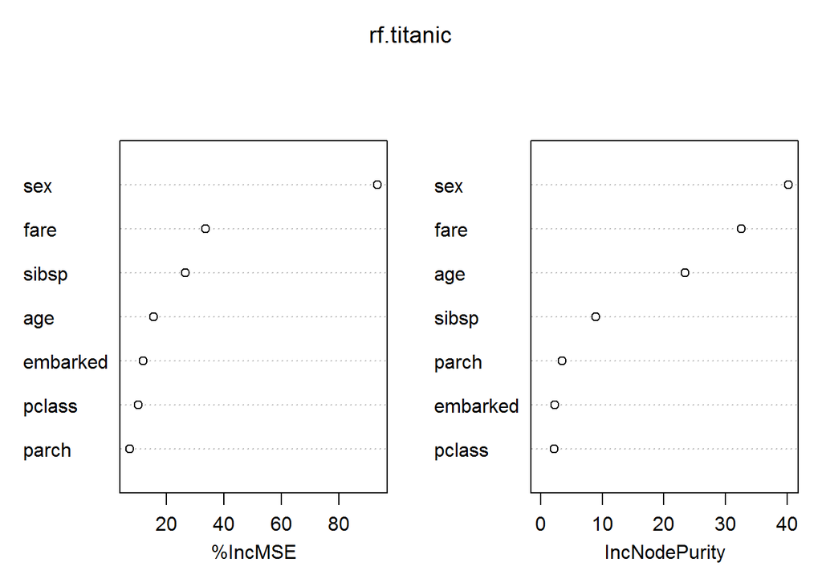

```r
varImpPlot(rf.titanic)
```

For the classification model:

```r
# Classification Model

importance(rf.titanic01)
```

```
##                  0         1 MeanDecreaseAccuracy MeanDecreaseGini
## pclass    9.985365  6.227571            11.637846         4.273848
## sex      57.207633 70.264456            86.083768        81.436346
## age      14.797445 -1.011604            11.938175        56.251740
## sibsp    26.488531  3.088241            25.807837        19.245102
## parch     4.381573  6.295932             7.342782         8.106748
## fare     17.416184 26.226156            29.877324        74.657358
## embarked  8.840642  4.639516             9.525474         3.920659
```

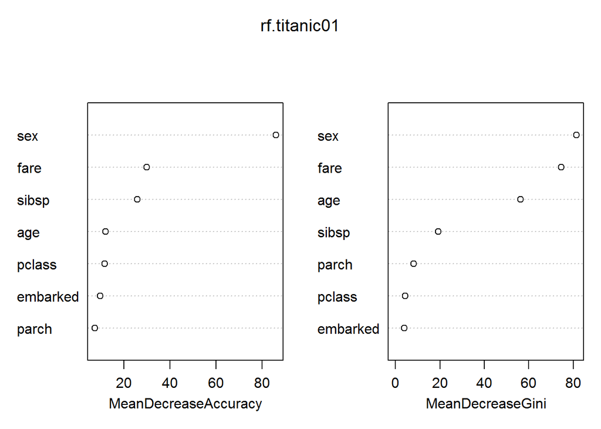

```r
varImpPlot(rf.titanic01)
```

## Part 7: Comparison of Error Rates

We can compare the error rate from different modelling approaches. For this comparison, we will use a forest comprising of 200 tree.The first will use a majority vote from all the tree in the forest to decided a classification.

```r
# The black line (majority vote)

# vector for test error
error.mv = rep(0,200)

for (i in 1:200){

  set.seed(1)

  # new classification model
  rf.titanicC <- randomForest(survived01 ~ . -survived, data = train, mtry = 7,importance=TRUE, ntree = i)

  # get predictions
  predictionC <- predict(rf.titanicC, newdata = test, type = "class")

  error.mv[i] <- mean(predictionC != actual01)
}
```

The second approach uses averages probabilities from each tree and predicts the class with the highest value.

```r
# blue line

# vector for test error
error.ave = rep(0,200)

for (j in 1:200){


  set.seed(1)
  # new classification model
  rf.titanicR <- randomForest(survived ~ . -survived01, data = train, mtry = 7,importance=TRUE, ntree = j)

  # get predictions
  predictionR <- predict(rf.titanicR, newdata = test)

  predctionR.class = ifelse(predictionR<=0.5, "0", "1")

  error.ave[j] <- mean(predctionR.class != actual)
}
```

[output not shown]

[output cut: 544 more lines]

[output not shown]

We can now plot all both of the results against the error from a single tree.

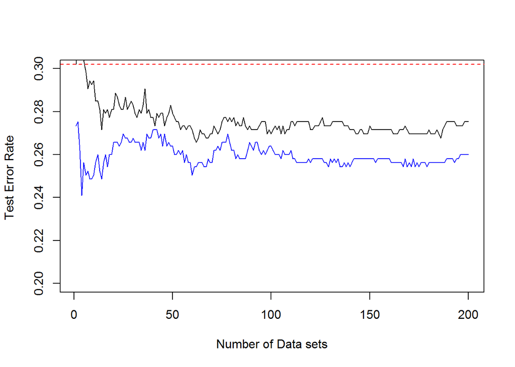

```r
# black line
plot(error.mv, xlab="Number of Data sets", ylab="Test Error Rate ", type="l"
     , ylim= c(0.2, 0.3))

#blue line
lines(error.ave, col="blue")

# add red line
abline(h=error.mv[1],lty=2,col="red")
```

## Part 8: Experiments with number of predictors at tree splits

We can now experiment with different values for mtry, to try and reduce the error.

```r
error.preds <- rep(0,7)
```

We will build 7 different forests, each with a different number of possible splits (1-7) at each branch.

```r
for (i in 1:length(error.preds)){

  rf.titanicM <- randomForest(survived01 ~ . -survived, data = train, mtry = i,importance=TRUE)

  predictionM <- predict(rf.titanicM, newdata = test, type="class")

  error.preds[i] <- mean(predictionM != actual01)

}
```

We can plot the results.

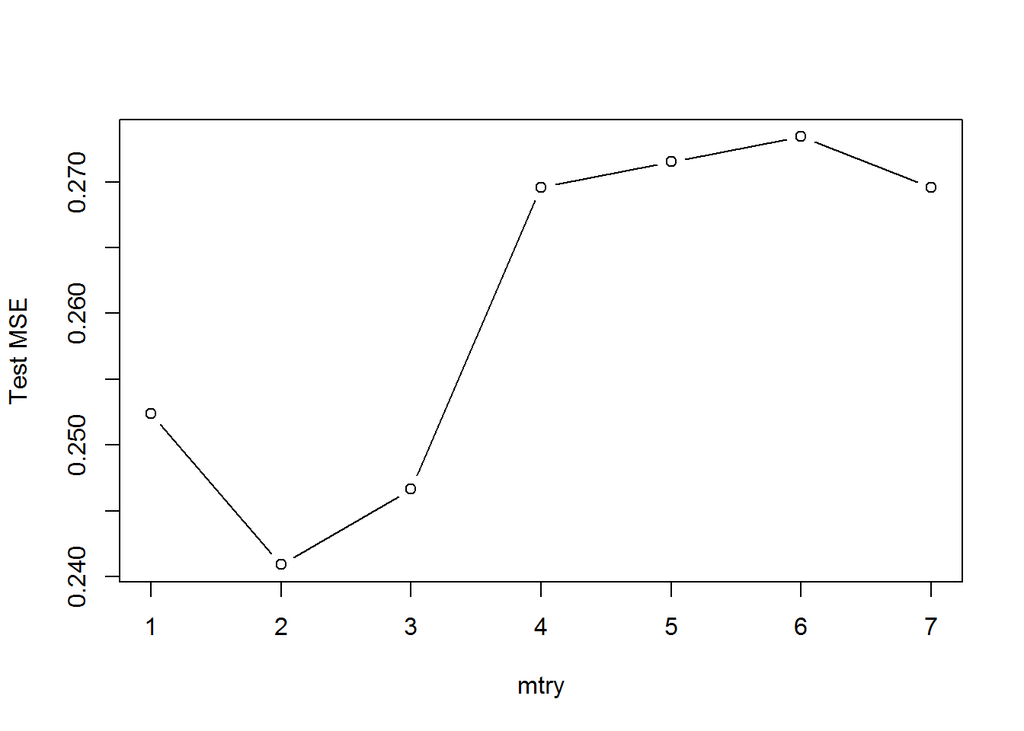

```r
plot(error.preds, type="b", xlab="mtry", ylab="Test MSE")
```

## Part 9: Errors vs ntrees

We will now experiment by altering the number of tree in each forest, and compare these with different values for mtry. We can visualise the results with a plot.

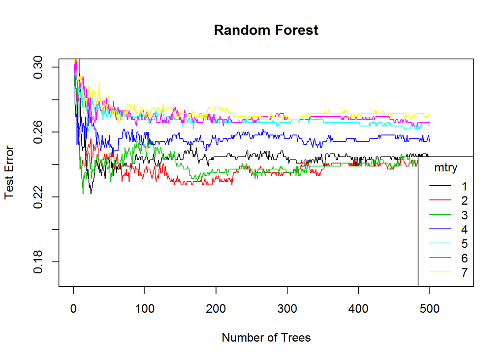

```r
plot(0,ylab="Test Error", xlab="Number of Trees", main="Random Forest", xlim=c(1,540), ylim =c(0.17,0.3))

errors.trees <- matrix(nrow=7, ncol=500 )

for (i in 1:7){


  for (j in 1:500) {

    set.seed(1)

    rf.titanicLoop <- randomForest(survived01 ~ . -survived, data = train, mtry = i,ntree = j ,importance=TRUE)

    predictionLoop <- predict(rf.titanicLoop, newdata = test, type="class")

    errors.trees[i, j] <- mean(predictionLoop!= actual01)

  }

  lines(errors.trees[i, ],col=i,type="l")

}

legend(title="mtry","bottomright",c("1","2","3","4","5","6","7"),lty=rep(1,7),col=1:7)
```